# Hate in Context

Week 5: Threatening Events and Hate Crime · LENS preview

Violeta Haas

Department of Political Science

School of Social Sciences and Philosophy

Trinity College Dublin

# This Week

# Theoretical backdrop

## Discussion: expert groups

**Split into Expert Group A and Expert Group B** (≈5 min).

### Group A — Social norms

1. Define social norms.
2. How do attitudes, social norms, and behavior differ? (provide an example for each)
3. Can behavior change without attitudes changing?

### Group B — Vicarious retribution

1. Sketch a schematic figure of the logic of vicarious retribution.
2. How do triggering events translate into hate crime?

Then: exchange between experts — Group A presents their definitions and examples; Group B presents their schematic figure.

## 1. What is a social norm?

[discussed in class]

## 2. Attitudes, behavior, and norms

[discussed in class]

[video not shown]

If the player fails, use: youtube.com/watch?v=o8BkzvP19v4

[discussed in class]

People often look for **environmental cues** — what others are doing — to figure out how to act (**descriptive norms**).

[figure not shown]

## Book recommendation

[figure not shown]

Bicchieri, C. (2017). *Norms in the wild: How to diagnose, measure, and change social norms*. Oxford University Press.

## Triggering event

[discussed in class]

## Shared grievance and collective blame / liability

[discussed in class]

## Vicarious retribution

[discussed in class]

## Prolonged intergroup conflict

[discussed in class]

## From trigger to hate crime: cognition and affect

[discussed in class]

Today’s papers ask how discrete shocks (triggering events) shift hostility — offline and online — including by changing what seems acceptable (social norms) and by redirecting blame onto uninvolved out-group members (vicarious retribution).

# Álvarez-Benjumea & Winter (2020)

## Overview

- **Research question:** Do terrorist attacks increase online hate speech — and do descriptive norms moderate that effect?
- **Y:** hate score of forum comments (1–9 hostility ratings)
- **X:** terrorist attacks during fieldwork (Würzburg & Ansbach, July 2016)
- **Moderator:** descriptive norms (no / weak / strong)
- **Theory:** attacks can weaken antiracist norms → latent xenophobic attitudes become behavior (hate speech)
- **Design:** unexpected event during survey/experiment (UEDS) + lab-in-the-field norm manipulation

## Unexpected Event During Survey (UEDS) design

Idea: attacks fall between two waves of the same experiment. Compare comments from the before wave vs the after wave.

**Comparison around the attacks**

Different participants in the same online experiment

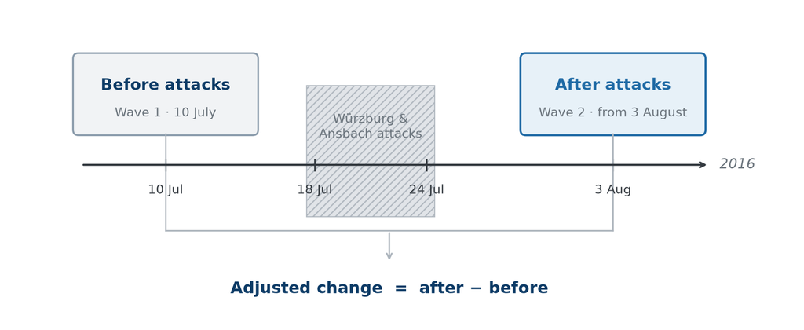

## Experimental forum

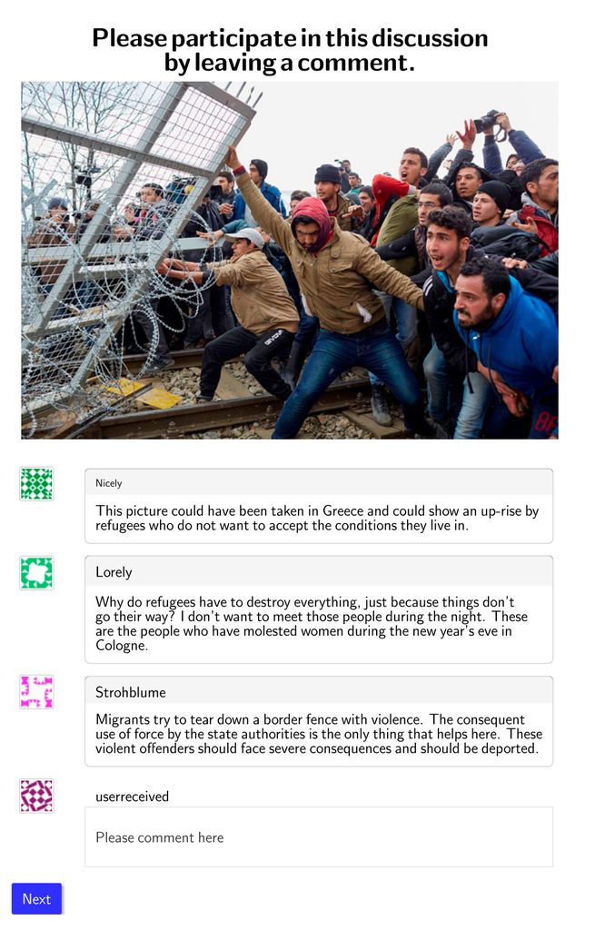

1. Participants join an online forum, see a prompt photo and seed comments that manipulate the descriptive anti-hate norm:
   - No norm: mix of hostile, neutral, and positive comments (norm ambiguous)
   - Weak norm: only neutral and positive comments (anti-hate norm signaled)
   - Strong norm: only very positive comments (anti-hate norm strongly signaled)
2. Participants then leave their own comment.
   - Comments are rated for hostility on a hate score from 1–9.

## Findings: mean change after attacks

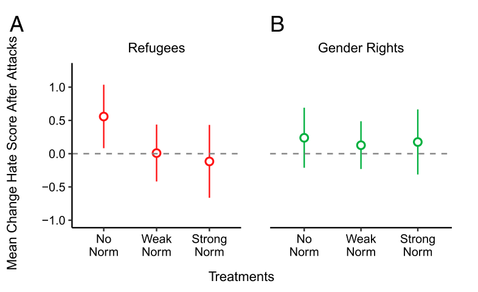

After the attacks, hate toward refugees rises when no norm is shown — but not under weak or strong norms. No parallel shift for unrelated group (i.e., gender rights).

## Findings: extreme comments

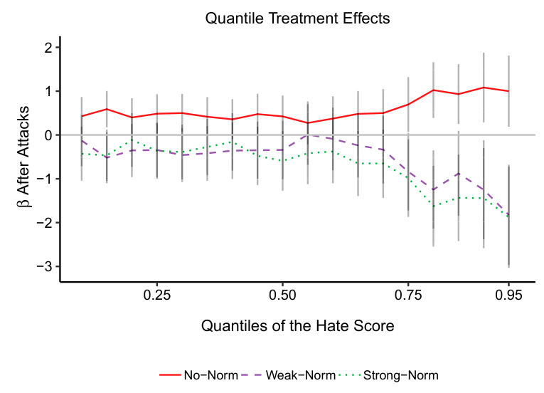

Descriptive norms especially dampen the most extreme comments: effects concentrate in the upper tail of the hate-score distribution.

## Group discussion (≈5 min)

**Two main responses to online hate (Siegel 2020): content moderation vs counter-speech.**

**In groups of 3–4:**

1. For each approach, collect 2 points in favor and 2 drawbacks.
2. What do Álvarez-Benjumea & Winter’s results speak for?
3. What do you think is the best way to deal with hate speech?

**Approach A — Content moderation**

Ban accounts/communities; enforce platform rules (and, where relevant, legal standards).

**Approach B — Counter-speech**

Challenge or dilute hate with opposing messages (users, campaigns, or designed interventions).

## Pros and cons

[discussed in class]

What do Álvarez-Benjumea & Winter speak for?

What is the best way to deal with hate speech?

# Riaz, Bischof & Wagner (2024)

## Overview

- **Research question:** Do local immigrant-attributed crimes raise hate crimes against refugees?
- **Y:** daily probability / count of hate crimes against refugees
- **X:** immigrant-attributed crime event
- **Theory:** vicarious retribution, i.e., natives retaliate against uninvolved out-group members after a triggering crime
- **Design:** regression discontinuity in time (RDiT) around local crime events (Germany, 2015–2019)

**Wait… RDiT? That sounds familiar!**

## Regression Discontinuity in Time (RDiT) design

**Idea:** a sudden local shock is a cutoff in time. Compare hate crimes from the before period vs the after period.

**Comparison around local crime events**

Same county, days close to the event

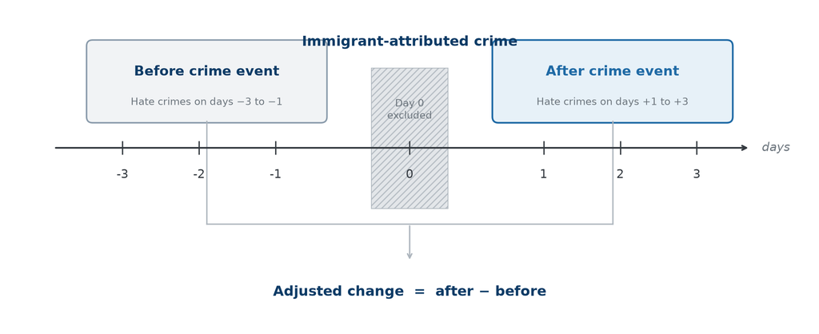

## Scope conditions

**Scope condition:** the subset of cases / conditions under which a theory applies.

Vicarious retribution applies when…

→ Riaz et al. (2024): considerable publicity is not necessary — smaller local triggering events can also have an effect.

How do natives—including potential hate crime perpetrators—hear about immigrant-attributed crime in their locality?

[discussed in class]

[discussed in class]

## Findings: daily hate-crime rate around events

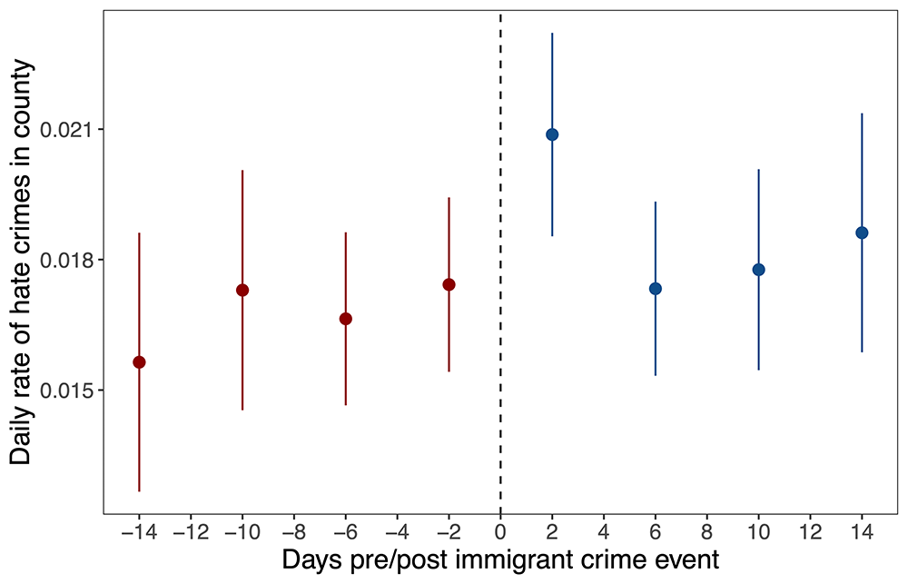

Hate crimes surge locally right after immigrant-attributed crimes — but the spike fades within ~4 days, consistent with an **emotional trigger** **(affect)** rather than lasting attitude change.

## Findings: where the backlash is stronger

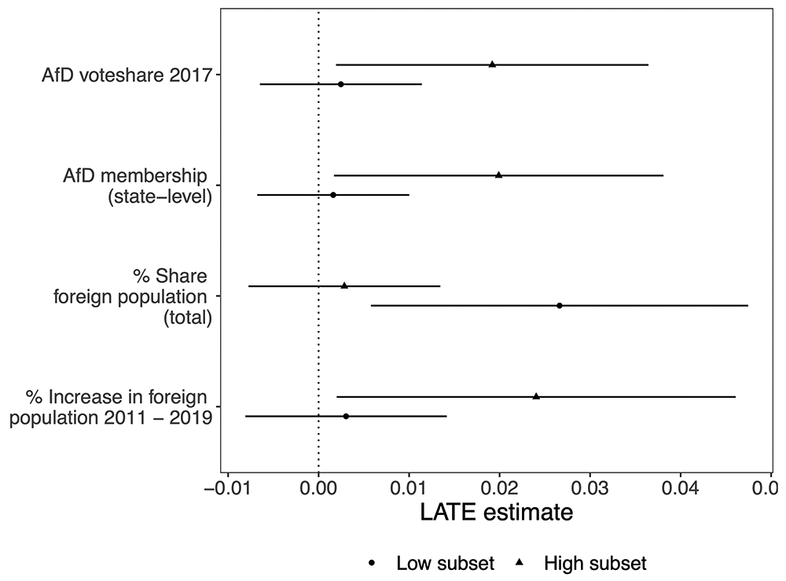

Backlash is stronger where **far-right mobilization potential** is high and where the foreign population has **recently increased** — not simply where many foreigners already live.

Anything else that didn’t convince you?

# Outlook

## Next week: political elites

**Week 6** (Mon 19/Wed 21 Oct): political elites and hate crime.

**Required readings**

- Romarri, A. (2020). Do far-right mayors increase the probability of hate crime? Evidence from Italy. Working paper.
- Dancygier, R. (2023). Hate crime supporters are found across age, gender, and income groups and are susceptible to violent political appeals. *Proceedings of the National Academy of Sciences*, 120(7), Article e2212757120.
- Zonszein, S., & Grossman, G. (2025). Voted in, standing out: Public response to immigrants’ political accession. *American Journal of Political Science*, 69(2), 718–733.

Weekly comments due **Sunday 18 Oct, 11:59 pm**.

# Questions?

# Goodbye!

See you next week.